# Machine Learning Assignment - course # 8

Tahrul Amin

November 14, 2017

# 1. Overview

The goal is to predict the manner in which the participants did exercise and classify to one of the five given categories.As i have to predict which class the participant will fall, i will use the classification related models that include classification tree, random forest, generalized boosting model, nayev bayes and linear discriminatory analysis model. I will use parellel processing for random forest and classification tree model buildup to speed up execution. After all the model is built, i found random forest model gave best accuracy which is >99%. So, i have not used model combination as random forest (RF) already predicted high accuracy.I measured the out of sample error which is very low. The RF model then applied to given 20 test data/quiz and prediction result came out fully correct

importing required library/packages

```r
library(caret)
library(randomForest)
library(parallel)
library(doParallel)
library(knitr)
library(rpart)
library(rpart.plot)
library(rattle)
```

## 2. Set Working directory and load data

```r
setwd("C:/coursera_project/cr8_prjct")

train_data <- read.csv("pml-training.csv")
test_data_original <- read.csv("pml-testing.csv")
```

## 3. Clean/pre-process the data - NZV,impute/missing data

```r
# create partition within the training dataset
inTrain  <- createDataPartition(train_data$classe,p=0.7,list=FALSE)
TrainSet <- train_data[inTrain, ]
TestSet  <- train_data[-inTrain, ]
dim(TrainSet)  #13737   160
```

```
## [1] 13737   160
```

```r
dim(TestSet)  ##5885    160
```

```
## [1] 5885  160
```

```r
# removing variables with Nearly Zero Variance
NZV <- nearZeroVar(TrainSet)
TrainSet <- TrainSet[, -NZV]
TestSet  <- TestSet[, -NZV]
test_data_original <- test_data_original[,-NZV]
dim(TrainSet)
```

```
## [1] 13737   104
```

```r
dim(TestSet)
```

```
## [1] 5885  104
```

```r
dim(test_data_original)
```

```
## [1]  20 104
```

```r
# removing variables with NA
TrainSet <- TrainSet[, colSums(is.na(TrainSet) )==0]
TestSet <- TestSet[, colSums(is.na(TestSet) )==0]
test_data_original <- test_data_original[, colSums(is.na(test_data_original) ) == 0]
dim(TrainSet)            #13737    59
```

```
## [1] 13737    59
```

```r
dim(TestSet)             #5885     59
```

```
## [1] 5885   59
```

```r
dim(test_data_original)  #20       59
```

```
## [1] 20 59
```

```r
# removing non-relevant variables to build model (1st 5 columns)
TrainSet <- TrainSet[, -(1:5)]
TestSet  <- TestSet[, -(1:5)]
test_data_original  <- test_data_original[, -(1:5)]
dim(TrainSet)             #13737    54
```

```
## [1] 13737    54
```

```r
dim(TestSet)              #5885     54
```

```
## [1] 5885   54
```

```r
dim(test_data_original)   #20       54
```

```
## [1] 20 54
```

```r
#Sys.time() #before building model
```

## 4. Model selection and model building

```r
# As we will predict which category the outcome of test data will fall, we will use classification related model
# Assuming model is non-linear. Data transformation is also less important for non-linear model

rm()
set.seed(5678)
########################
#LDA: Applying linear discrimant analysis(LDA) assuming variables havee a multivariate distribution within each class
modlda = train(classe ~ ., data = TrainSet, method="lda")
modlda$results # Accuracy is not good. Not a good model for our dataset
```

```
##   parameter  Accuracy     Kappa AccuracySD     KappaSD
## 1      none 0.7079049 0.6304403  0.0052782 0.006693499
```

```r
########################
#Naive Bayes: Applying Naive Bayes model assuming data follow a probabilistic model
#Naive Bayes assumes independence between features for model building
rm()

cluster <- makeCluster(detectCores() - 1) # convention to leave 1 core for OS
registerDoParallel(cluster)
modnb = train(classe ~ ., data = TrainSet, method="nb")
modnb$results # Accuracy is not good. Not a good model for our dataset.predictor variables may not be independant
```

```
##   usekernel fL adjust  Accuracy     Kappa AccuracySD    KappaSD
## 1     FALSE  0      1 0.5103035 0.3924191 0.03818031 0.04137244
## 2      TRUE  0      1 0.7550249 0.6891388 0.01079543 0.01404028
```

```r
stopCluster(cluster)
registerDoSEQ()

plda = predict(modlda,TestSet)
pnb = predict(modnb,TestSet)
table(plda,pnb) # The model LDA, NB also does not have similar prediction
```

```
##     pnb
## plda    A    B    C    D    E
##    A 1463   62  115   86   39
##    B   88  724  101   55  132
##    C  291   61  694   34   33
##    D  228   23  139  630   93
##    E   27   89   23   42  613
```

```r
########################
#GBM: Applying Generalized Boosted Model(GBM)-because we are predicting with trees and want to combine weak predictors to #make stronger
set.seed(12345)
rm()
control_gbm <- trainControl(method="cv", number = 5)  #to avoid overfitting, using cross validation
modFitGBM  <- train(classe ~ ., data=TrainSet, method = "gbm",trControl = control_gbm, verbose = FALSE)
modFitGBM$finalModel
```

```
## A gradient boosted model with multinomial loss function.
## 150 iterations were performed.
## There were 53 predictors of which 41 had non-zero influence.
```

```r
predict_GBM <- predict(modFitGBM,newdata=TestSet)
confusion_GBM <- confusionMatrix(predict_GBM, TestSet$classe)
confusion_GBM #Accuracy is very good
```

```
## Confusion Matrix and Statistics
##
##           Reference
## Prediction    A    B    C    D    E
##          A 1667   22    0    0    0
##          B    6 1106    3    4    5
##          C    0   11 1018    8    3
##          D    1    0    4  950   14
##          E    0    0    1    2 1060
##
## Overall Statistics
##
##                Accuracy : 0.9857
##                  95% CI : (0.9824, 0.9886)
##     No Information Rate : 0.2845
##     P-Value [Acc > NIR] : < 2.2e-16
##
##                   Kappa : 0.9819
##  Mcnemar's Test P-Value : NA
##
## Statistics by Class:
##
##                      Class: A Class: B Class: C Class: D Class: E
## Sensitivity            0.9958   0.9710   0.9922   0.9855   0.9797
## Specificity            0.9948   0.9962   0.9955   0.9961   0.9994
## Pos Pred Value         0.9870   0.9840   0.9788   0.9804   0.9972
## Neg Pred Value         0.9983   0.9931   0.9983   0.9972   0.9954
## Prevalence             0.2845   0.1935   0.1743   0.1638   0.1839
## Detection Rate         0.2833   0.1879   0.1730   0.1614   0.1801
## Detection Prevalence   0.2870   0.1910   0.1767   0.1647   0.1806
## Balanced Accuracy      0.9953   0.9836   0.9938   0.9908   0.9895
```

```r
#########################
# Cross validation using k-fold and build model using classification tree and random forest
#set parallel processing as model need speed
cluster <- makeCluster(detectCores() - 1) # convention to leave 1 core for OS
registerDoParallel(cluster)
#Using CLASSIFICATION TREE - trying to identify class based on homogeneity within each group
rm()
set.seed(6789)
control <- trainControl(method="cv", number=5) #cross validation is important to restrict model overfitting
fit_rpart <- train(classe ~ ., data = TrainSet, method = "rpart", trControl = control)
print(fit_rpart)
```

```
## CART
##
## 13737 samples
##    53 predictor
##     5 classes: 'A', 'B', 'C', 'D', 'E'
##
## No pre-processing
## Resampling: Cross-Validated (5 fold)
## Summary of sample sizes: 10991, 10990, 10990, 10989, 10988
## Resampling results across tuning parameters:
##
##   cp          Accuracy   Kappa
##   0.03931441  0.5274816  0.39196012
##   0.06004815  0.4144267  0.20679384
##   0.11463737  0.3331280  0.07429771
##
## Accuracy was used to select the optimal model using the largest value.
## The final value used for the model was cp = 0.03931441.
```

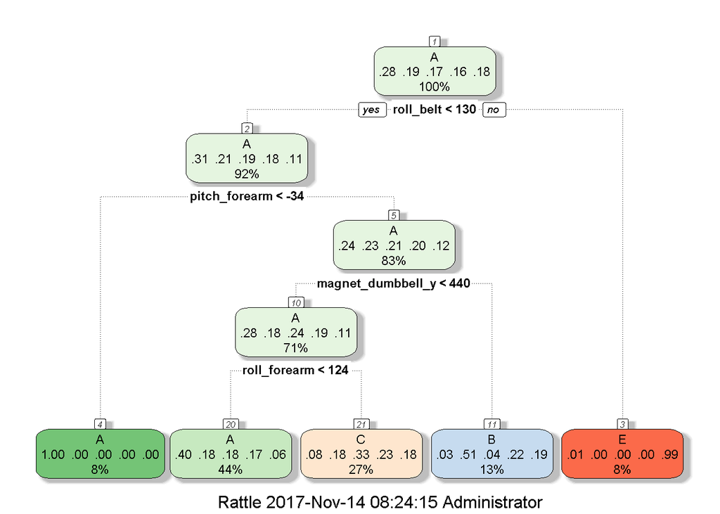

```r
stopCluster(cluster)
registerDoSEQ()
fancyRpartPlot(fit_rpart$finalModel)
```

```r
# predict outcomes using Testset(30% from TrainSet)
predict_rpart <- predict(fit_rpart, TestSet)
# Show prediction result
confusion_rpart <- confusionMatrix(TestSet$classe, predict_rpart)
accuracy_rpart <- confusion_rpart$overall[1]
accuracy_rpart
```

```
##  Accuracy
## 0.4961767
```

```r
#The classification model does not predict well
####################################
#set parallel processing
cluster <- makeCluster(detectCores() - 1) # convention to leave 1 core for OS
registerDoParallel(cluster)
# using RANDOM FOREST - this model normally gives higher accuracy although take more memory to run
# we will also be able to find correlated predictors using 'random forest' method
rm()
fit_rf <- train(classe ~ ., data = TrainSet, method = "rf", trControl = control)#using cross validation to avoid overfitting
print(fit_rf)
```

```
## Random Forest
##
## 13737 samples
##    53 predictor
##     5 classes: 'A', 'B', 'C', 'D', 'E'
##
## No pre-processing
## Resampling: Cross-Validated (5 fold)
## Summary of sample sizes: 10989, 10989, 10990, 10990, 10990
## Resampling results across tuning parameters:
##
##   mtry  Accuracy   Kappa
##    2    0.9941035  0.9925408
##   27    0.9963600  0.9953954
##   53    0.9942488  0.9927247
##
## Accuracy was used to select the optimal model using the largest value.
## The final value used for the model was mtry = 27.
```

```r
stopCluster(cluster)
registerDoSEQ()
# predict outcomes using Testset(30% from TrainSet)
predict_rf <- predict(fit_rf, TestSet)
# Show prediction result
confusion_rf <- confusionMatrix(TestSet$classe, predict_rf)
accuracy_rf <- confusion_rf$overall[1]
accuracy_rf
```

```
##  Accuracy
## 0.9976211
```

```r
# Among all the above models, random forest performed the best and has been chosen for this assignment
# for categorical outcome, model accuracy is the objective.

#4: Let's see out-of-sample error rate
out_of_sample_error = 1-accuracy_rf
out_of_sample_error
```

```
##    Accuracy
## 0.002378929
```

```r
#####################################
```

# 5. Conclusion and Prediction on original test data set

The Random Forest model predicts very good. So, combining predictors not needed which may overfit.Applying random forest model to original test set CSV file

```r
rm()
predict(fit_rf, test_data_original)
```

```
##  [1] B A B A A E D B A A B C B A E E A B B B
## Levels: A B C D E
```

```r
#Sys.time() #End assignment
```